# Aureus boxplot

Agustín Diez Castllo

4/21/2022

```r
if (!require("ggplot2")) install.packages("ggplot2")
library(ggplot2)
```

But let see an example with golden coins from roman times. We got 91 coins from diferent authorities that have been found in Hispania and we like to see if there are some differences in weight thru time. First we’ve weighted each of the aureus (this is how the Romans called their golden coins) and have noted the Authority on them -Authority-.

```r
Authority1 <- c(7.02, 6.95, 7.03, 6.82, 6.87, 6.91, 6.95, 6.89, 6.95, 6.78, 6.25, 5.48)
Authority2 <- c(6.91, 7.04)
Authority3 <- c(6.38, 6.23, 7.11, 6.84, 7.08, 5.73, 6.92, 7.00, 6.14, 6.84, 5.69, 7.02,
                5.84, 6.88, 6.96, 5.83, 7.03, 7.06, 6.79, 7.01, 6.87, 6.03)
Authority4 <- c(6.91, 7.03, 7.19, 6.26)
Authority5 <- c(6.01, 6.84, 7.03, 7.09, 6.44, 6.20, 7.26, 7.14, 6.98, 6.95, 6.82, 5.78)
Authority6 <- c(6.89, 6.06, 7.10, 5.76, 5.93, 7.08, 6.37, 7.07, 5.96, 7.26, 6.96, 6.96,
                6.11, 6.92, 6.16, 7.21)
Authority7 <- c(6.89, 6.05, 5.95, 7.19, 5.71, 7.04, 6.83, 7.02)
Authority8 <- c(6.04, 5.83, 6.94, 7.23, 5.83, 7.19, 7.17, 5.93)
Authority9 <- c(6.57)
Authority10 <- c(6.35, 6.28, 6.37, 6.25)
Authority11 <- c(6.30, 5.47)
Authority <- factor(c(rep("Nerón", 12),rep("Galba", 2),rep("Vespasiano", 22),rep("Tito", 4),
                      rep("Trajano", 12), rep("Adriano", 16),rep("Antonino Pío", 8),
                      rep("Marco Aurelio", 8), rep("Didio Juliano", 1), rep("Heliogábalo", 4),
                      rep("Alejandro Severo", 2)))
```

Now we put all this weights together

```r
weights <- c(Authority1, Authority2, Authority3, Authority4, Authority5, Authority6,
             Authority7, Authority8, Authority9, Authority10, Authority11)
```

And we’re ready for our boxplot

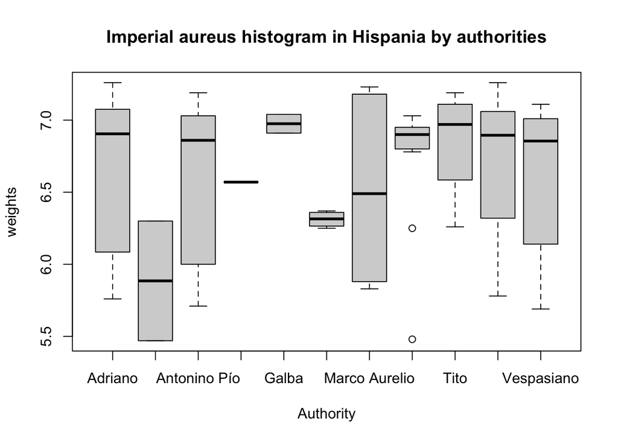

```r
boxplot(weights~Authority,main="Imperial aureus histogram in Hispania by authorities")
```

That’s fine, but we want something more representative. But let me build a data frame first

```r
au<-data.frame(as.numeric(weights),Authority)
```

Now, we’re ready for the violin plot

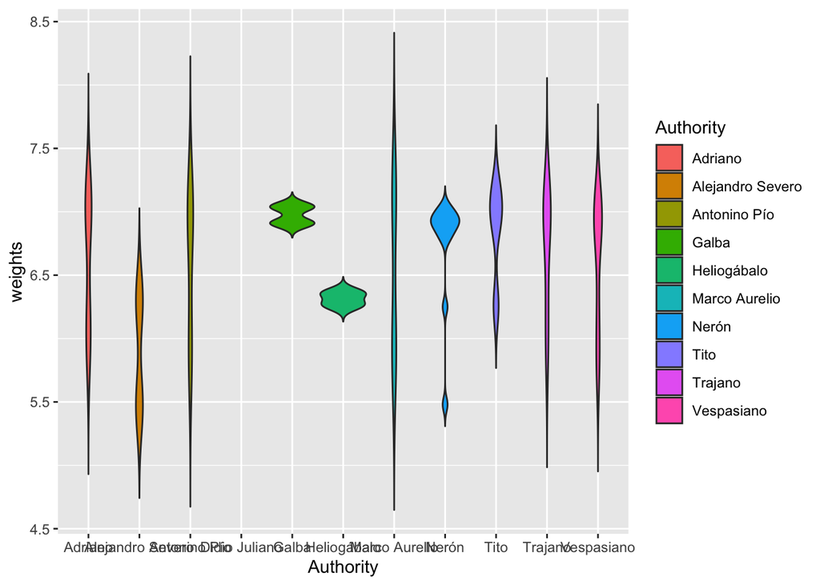

```r
p <- ggplot(au, aes(x=Authority, y=weights,fill=Authority))+geom_violin(trim=FALSE)
p
```

Cool, but we want to chronologically order the Authorities

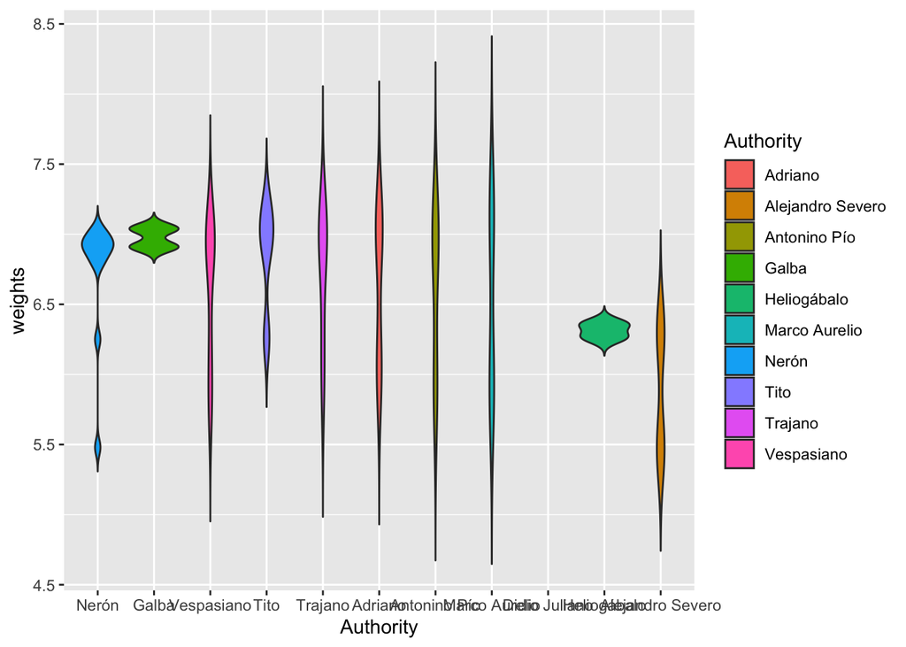

```r
p<-p + scale_x_discrete(limits=unique(as.character(Authority)))
p
```

Not bad, but it will be cool to read the Authorities names.

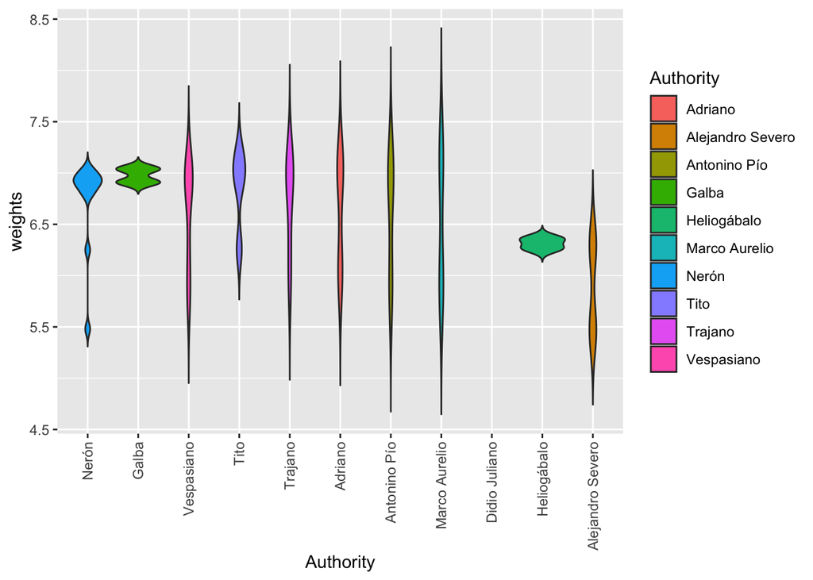

```r
p<-p+ theme(axis.text.x = element_text(angle = 90, vjust = 0.5, hjust=1))
p
```

Better, but how many aureus are in the sample?

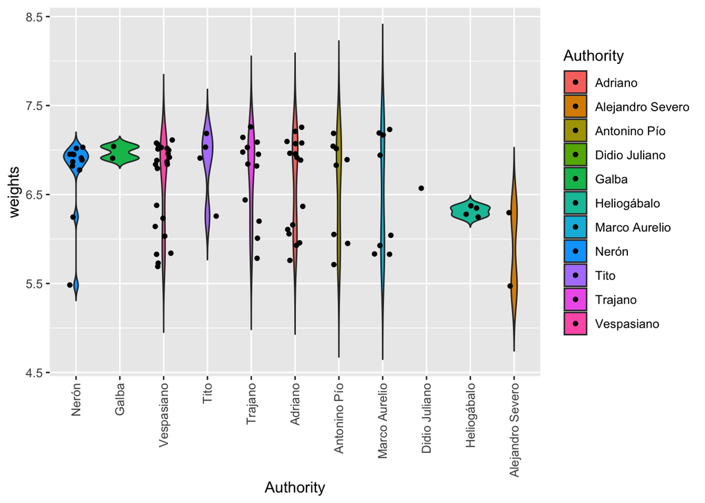

```r
p<-p +
 theme(axis.text.x = element_text(angle = 90, vjust = 0.5, hjust=1)) +
  geom_jitter(shape=16, position=position_jitter(0.2))
p
```

Much better, but let see if there is someway to add the plain boxplot to this.

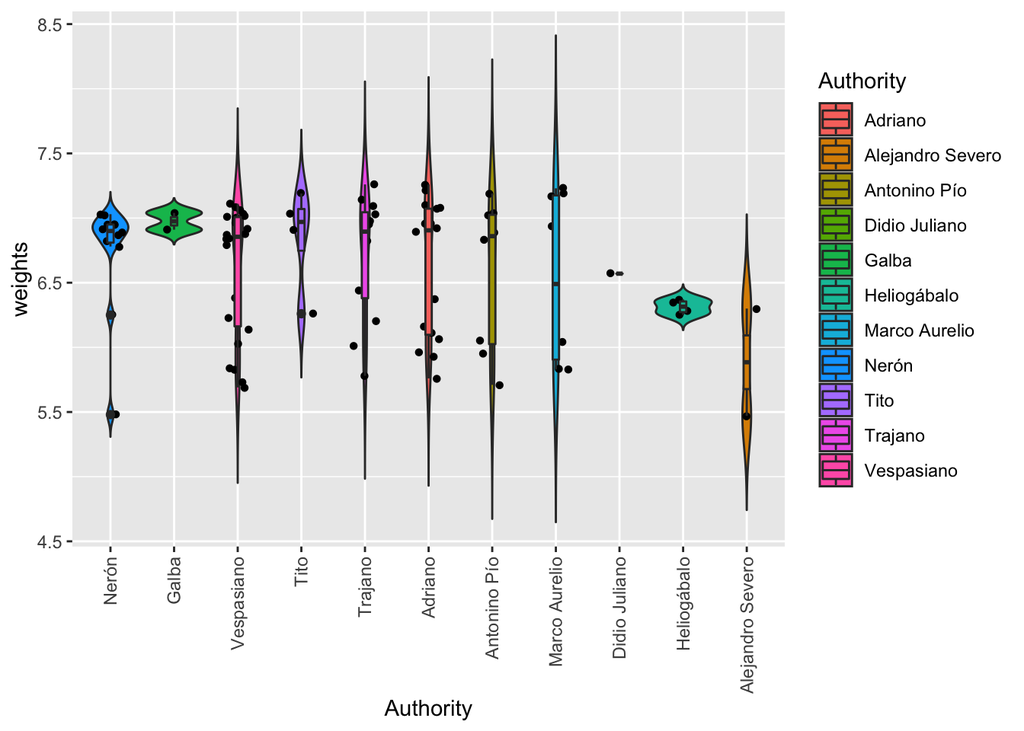

```r
p<-p+geom_boxplot(width=0.1)
p
```

OK, but the legend is not this useful

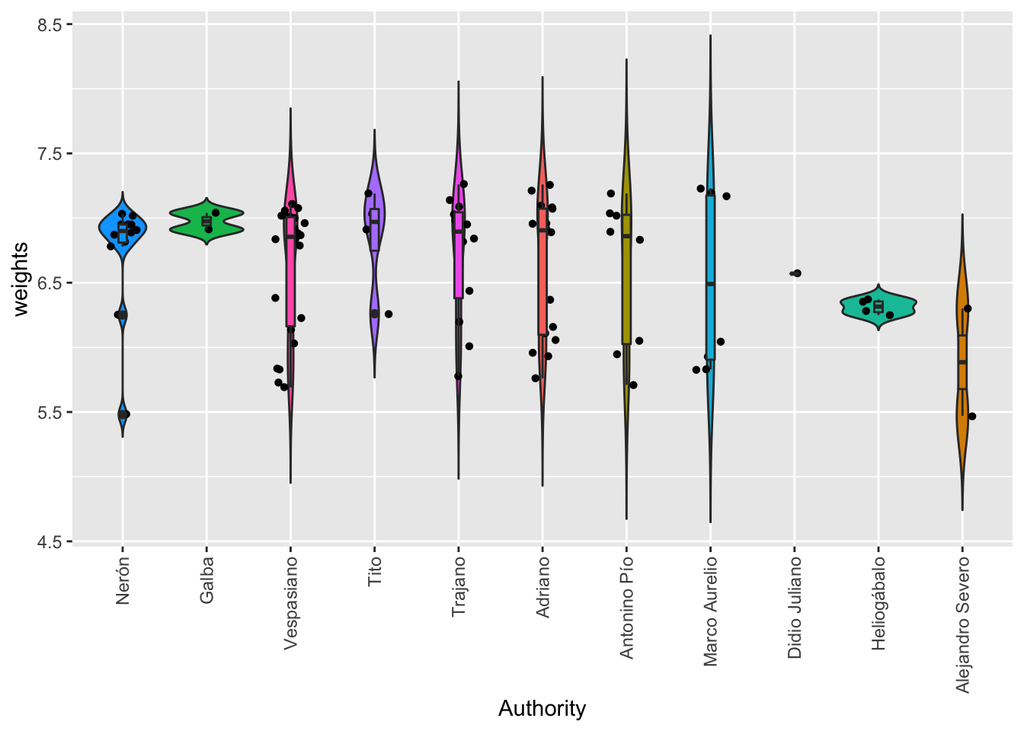

```r
p+theme(legend.position="none")
```

That’s all.